```python
import pandas as pd
import numpy as np
import faraway.datasets.uswages as uswages
import matplotlib.pyplot as plt
import seaborn as sns
import mglearn
```

```python
from sklearn.model_selection import train_test_split
from sklearn.metrics import r2_score
from sklearn import preprocessing

from sklearn.linear_model import LinearRegression
from sklearn.ensemble import RandomForestRegressor
from sklearn.neural_network import MLPRegressor

import warnings
warnings.filterwarnings("ignore")
```

# Regression Model Analysis

In this notebook are implemented regression models in order to predict the wage of a worker on the dataset uswages from the faraway package.

For that purpose:

```
-  The data has been imported and checked for too high correlated variables.
-  Due to having only 10 features, all of them are going to be used in the model.
-  The outliers of the dataset has been removed based on having wage as a normal distribution, i.e.

                               |(data_point) - mean(wage)| > 2 * std(wage)

-  The data has been splitted into a test set and a training set.
```

Then, different models have been tested:

```
- An implementation of random results, naive mean and Linear Regression.
- An implementation of a Multilayer perceptrons (MLPs) model, also called feed-forward neural networks or just neural networks: it has been tested without tunning the hyperparameters and then with the tunned hyperparameters.
- An implementation of a Random Forest Regressor: it has been tunned the hyperparameters.
```

Once the models have been implemented and compare it, it has been choosed the one that gives better results.

## Datapreprocessing

```python
dataset = uswages.load()
```

```python
# Cheking for features too correlated
cor_matrix = dataset.corr().abs()
upper_tri = cor_matrix.where(np.triu(np.ones(cor_matrix.shape),k=1).astype(np.bool))

to_drop = [column for column in upper_tri.columns if any(upper_tri[column] > 0.95)]
print(); print(to_drop)
```

```
[]
```

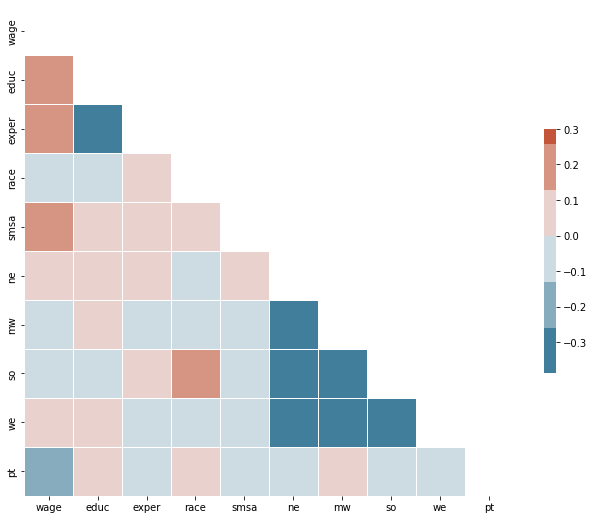

```python
# Compute the correlation matrix
corr = dataset.corr()

# Generate a mask for the upper triangle
mask = np.triu(np.ones_like(corr, dtype=bool))

# Set up the matplotlib figure
f, ax = plt.subplots(figsize=(11, 9))

# Generate a custom diverging colormap
cmap = sns.diverging_palette(230, 20, as_cmap=False)

# Draw the heatmap with the mask and correct aspect ratio
sns.heatmap(corr, mask=mask, cmap=cmap, vmax=.3, center=0,
            square=True, linewidths=.5, cbar_kws={"shrink": .5})
```

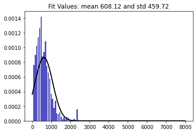

```python
from scipy.stats import norm

# Checking for outliers
mu, std = norm.fit(dataset.wage)

plt.hist(dataset.wage, bins='auto',density=True, color='#0504aa',alpha=0.7, rwidth=0.85)
xmin, xmax = plt.xlim()
x = np.linspace(0, 8000, 100)
p = norm.pdf(x, mu, std)

plt.plot(x, p, 'k', linewidth=2)
title = "Fit Values: mean {:.2f} and std {:.2f}".format(mu, std)
plt.title(title)

plt.show()
```

```python
# Removing outliers
def outlier_detection(row):
    if(abs(row - 608.1178649999999) > 2*459.83262947376426):
        return 1
    else: return 0

dataset['aux_column'] = dataset.apply(lambda row: outlier_detection(row['wage']), axis=1)
dataset = dataset.drop(dataset[dataset.aux_column == 1].index)
dataset.drop(['aux_column'], axis=1)
```

|  | wage | educ | exper | race | smsa | ne | mw | so | we | pt |
| --- | --- | --- | --- | --- | --- | --- | --- | --- | --- | --- |
| 0 | 771.60 | 18 | 18 | 0 | 1 | 1 | 0 | 0 | 0 | 0 |
| 1 | 617.28 | 15 | 20 | 0 | 1 | 0 | 0 | 0 | 1 | 0 |
| 2 | 957.83 | 16 | 9 | 0 | 1 | 0 | 0 | 1 | 0 | 0 |
| 3 | 617.28 | 12 | 24 | 0 | 1 | 1 | 0 | 0 | 0 | 0 |
| 4 | 902.18 | 14 | 12 | 0 | 1 | 0 | 1 | 0 | 0 | 0 |
| ... | ... | ... | ... | ... | ... | ... | ... | ... | ... | ... |
| 1995 | 468.09 | 16 | 18 | 0 | 1 | 0 | 1 | 0 | 0 | 0 |
| 1996 | 584.00 | 16 | 15 | 0 | 1 | 0 | 0 | 0 | 1 | 0 |
| 1997 | 427.35 | 13 | 4 | 0 | 1 | 1 | 0 | 0 | 0 | 0 |
| 1998 | 185.19 | 18 | 25 | 0 | 1 | 1 | 0 | 0 | 0 | 0 |
| 1999 | 712.25 | 12 | 10 | 0 | 1 | 0 | 0 | 1 | 0 | 0 |

1932 rows × 10 columns

```python
# Splitting the data into training and test set
target = dataset.wage
X = dataset.loc[:, dataset.columns != 'wage']
X_train,X_test,y_train,y_test = train_test_split(X, target, test_size=0.2, random_state=1)
```

## Regression Algorithm

### Random model, Naive mean model and Linear Regression model

```python
# Implementing the Random model, Naive mean model and Linear Regression model.
results = pd.DataFrame(index=X_test.index, columns=['Random','Naive_mean','LR','Actual'])

results.Actual = y_test
results.Random = np.random.uniform(y_train.min(), y_train.max(), y_test.shape)
results.Naive_mean = y_train.mean()

model = LinearRegression()
model.fit(X_train, y_train)
results.LR =model.predict(X_test)

results['|Random-Actual|'] = abs(results.Random - results.Actual)
results['|Naive_Mean-Actual|'] = abs(results.Naive_mean - results.Actual)
results['|LR-Actual|'] = abs(results.LR - results.Actual)

metrics = pd.DataFrame(index = ['MSE', 'MAE','R2'], columns = ['Random','Naive_mean','LR'])

n_test = len(results)

for m in metrics.columns:
    metrics.at['MSE',m]= np.sum(results.apply(lambda r: (r.Actual - r[m])**2,axis=1))/n_test
    metrics.at['MAE',m] = np.sum(abs(results.Actual - results[m]))/n_test
    metrics.at['R2',m] = r2_score(y_test, results[m])
metrics
```

|  | Random | Naive_mean | LR |
| --- | --- | --- | --- |
| MSE | 372222.768314 | 94092.383194 | 55289.827759 |
| MAE | 505.935892 | 251.177009 | 186.700028 |
| R2 | -2.994423 | -0.009731 | 0.40667 |

### Neural Network model without tunning

We will start implementing a simple neural network where the hyperparameters, i.e. the parameters whose value is used to control the learning process, are not defined.

```python
# Neural Network NOT TUNNED implementation
model = MLPRegressor(hidden_layer_sizes=5,max_iter=2000)
model.fit(X_train, y_train)

results['MLP'] = model.predict(X_test)
results['|MLP-Actual|'] = abs(results.MLP - results.Actual)

metrics.at['MSE','MLP']= np.sum(results.apply(lambda r: (r.Actual - r['MLP'])**2,axis=1))/n_test
metrics.at['MAE','MLP'] = np.sum(abs(results.Actual - results['MLP']))/n_test
metrics.at['R2','MLP'] = r2_score(y_test, results['MLP'])

metrics
```

|  | Random | Naive_mean | LR | MLP |
| --- | --- | --- | --- | --- |
| MSE | 372222.768314 | 94092.383194 | 55289.827759 | 53902.034556 |
| MAE | 505.935892 | 251.177009 | 186.700028 | 184.341479 |
| R2 | -2.994423 | -0.009731 | 0.40667 | 0.421563 |

### Neural Network tunning process

Now we have to split the training set into a validation set and a tunning set. Then, we select as 10 the number of times the neural network is going to be trained and tested in order to test stability.

We will select the parameters based on the minimization of RSME.

```python
# We have to divide the training set to obtain a validation test
X_train_s, X_tune, y_train_s, y_tune = train_test_split(X_train, y_train, test_size=0.2, random_state=1)

# We set a number of repetitions for tunning parameters
num_repetition = 10
```

We have to choose between different activation functions, i.e. nonlinear function applied to the result of the linear model in a hidden unit:

$$ h[i] = \phi( \sum_{i=0}^k \omega_{(i,0)} x[i] ) $$

where $h[i]$ refers to node $i$ of the hidden layer, $\omega_{(i,0)}$ to the weight from node $i$ of previous layer, $x[i]$ to the node of previous layer and $\phi$ to the activation function.

The activation function allows the neural network to learn much more complicated functions than a linear model could. The possible activation functions are: identity $id(x)=x$, logistic sigmoid function $f(x)=1/(1+exp(-x))$, tanh $f(x)=tanh(x)$ and relu $f(x)=max(x,0)$.

We also have to choose a solver option, i.e. the function that will optimize the weight selection. The possible activation functions are: lbfgs, sgd *(Stochastic Gradient Descent)* and adam *(Optimized Stochastic Gradient Descend)*.

```python
# Create a placeholder for experimentations
activation_options = ['identity', 'logistic', 'tanh', 'relu']
solver_options = ['lbfgs','sgd','adam']

my_index = pd.MultiIndex.from_product([activation_options,solver_options], names=('activation', 'solver'))
tune_df = pd.DataFrame(index = my_index, columns=['R{}'.format(i) for i in range(num_repetition)])

# Choosing best activation and solver functions
n = len(y_tune)
for activation_o in activation_options:
    for solver_o in solver_options:
        for rep in tune_df.columns:
            car_mlp = MLPRegressor(hidden_layer_sizes=(5), max_iter=2000,
                                   activation=activation_o,solver=solver_o)

            car_mlp.fit(X_train_s, y_train_s)
            y_tune_predict = car_mlp.predict(X_tune)
            RSME = np.sqrt(np.sum((y_tune_predict - y_tune)**2)/n)

            tune_df.at[(activation_o,solver_o),rep] = RSME

tune_df['Mean'] = tune_df[
    ['R{}'.format(i) for i in range(num_repetition)]].mean(axis=1)
tune_df['Min'] = tune_df[
    ['R{}'.format(i) for i in range(num_repetition)]].min(axis=1)
tune_df.sort_values('Min')
```

[output not shown]

We have to choose between different structure of the neural network. It has been decided to test 15 one layered neural networks, from (1) to (15), and 100 two layered neural networks from (1,1) to (10,10) (all possible configurations).

```python
# Defining all possible configurations
PossibleNetStrct = []
PossibleNetString = []

for i in range(1,16):
    netStruct = [i]
    PossibleNetStrct.append(netStruct)
    PossibleNetString.append(str(netStruct))

for i in range(1,11):
    for j in range(1,11):
        netStruct = [i,j]
        PossibleNetStrct.append(netStruct)
        PossibleNetString.append(str(netStruct))
tune_df = pd.DataFrame(np.nan, index =PossibleNetString,
                      columns = ['R{}'.format(i) for i in range(num_repetition)])

n = len(y_tune)

# Testing all possible configuration
for i,netStr in enumerate(PossibleNetStrct):
    RowName = PossibleNetString[i]
    for rep in tune_df.columns:

        car_mlp = MLPRegressor(hidden_layer_sizes=netStr, activation = 'relu',
                       solver='lbfgs', max_iter=2000)
        car_mlp.fit(X_train_s, y_train_s)

        y_tune_predict = car_mlp.predict(X_tune)
        RSME = np.sqrt(np.sum((y_tune_predict - y_tune)**2)/n)

        tune_df.at[RowName, rep] = RSME
    print(netStr)

tune_df['Mean'] = tune_df[
    ['R{}'.format(i) for i in range(num_repetition)]].mean(axis=1)
tune_df['Min'] = tune_df[
    ['R{}'.format(i) for i in range(num_repetition)]].min(axis=1)
tune_df.sort_values('Min')
```

```
[1]
[2]
[3]
[4]
[5]
[6]
[7]
[8]
[9]
[10]
[11]
[12]
[13]
[14]
[15]
```

[output cut: 100 more lines]

|  | R0 | R1 | R2 | R3 | R4 | R5 | R6 | R7 | R8 | R9 | Mean | Min |
| --- | --- | --- | --- | --- | --- | --- | --- | --- | --- | --- | --- | --- |
| [12] | 234.942600 | 235.996050 | 237.425284 | 235.822054 | 235.916872 | 235.418173 | 235.510818 | 233.876914 | 235.374240 | 237.952434 | 235.823544 | 233.876914 |
| [7, 8] | 238.004961 | 235.410230 | 234.554164 | 234.075676 | 237.472549 | 237.974251 | 238.982652 | 236.011942 | 239.369731 | 241.879600 | 237.373576 | 234.075676 |
| [10, 10] | 234.899235 | 240.614691 | 234.270122 | 235.521208 | 240.007134 | 240.377838 | 236.452957 | 234.765094 | 236.225521 | 235.885711 | 236.901951 | 234.270122 |
| [3, 7] | 242.218058 | 240.622954 | 234.287729 | 236.667561 | 236.041478 | 236.707293 | 240.194060 | 236.801975 | 240.322368 | 306.147518 | 245.001099 | 234.287729 |
| [13] | 236.251042 | 235.957326 | 236.105813 | 235.227544 | 234.323368 | 234.887236 | 238.532900 | 236.507997 | 234.713345 | 235.763092 | 235.826966 | 234.323368 |
| ... | ... | ... | ... | ... | ... | ... | ... | ... | ... | ... | ... | ... |
| [1] | 306.147641 | 240.541568 | 240.545299 | 306.147518 | 242.489286 | 242.723502 | 240.552524 | 240.543581 | 242.324600 | 306.147518 | 260.816304 | 240.541568 |
| [1, 3] | 306.147518 | 306.147518 | 306.147518 | 306.147520 | 242.810476 | 240.541940 | 242.260180 | 306.147518 | 306.147518 | 245.492668 | 280.799037 | 240.541940 |
| [1, 2] | 306.147518 | 306.147518 | 306.147518 | 306.147518 | 306.147519 | 306.147518 | 240.551464 | 245.119380 | 240.542792 | 242.545592 | 280.564434 | 240.542792 |
| [1, 1] | 306.147518 | 306.147518 | 306.147518 | 306.147518 | 306.147518 | 240.544613 | 306.147518 | 306.147518 | 306.147518 | 306.147518 | 299.587227 | 240.544613 |
| [1, 7] | 306.147518 | 306.147518 | 240.546259 | 247.737155 | 306.147518 | 285.028172 | 289.941953 | 306.147518 | 306.147518 | 241.172518 | 283.516365 | 240.546259 |

115 rows × 12 columns

In this case, we would have to choose between different learning rate options: constant, invscaling and adaptative. However, due to we had choose as solver function *lbfgs* the learning rate don't have sense.

And also we would have to choose a value for the initial learning rate. However, as with the learning rate due to selecting as solver option *lbfgs* this is not going to be used.

```python
#LR_options = ['constant','invscaling','adaptive']
#LRI_options = [0.0001,0.001,0.005,0.01,0.05,0.1]
#
#my_index = pd.MultiIndex.from_product([LR_options,LRI_options],
#                                     names=('LR', 'rate'))
#
#tune_df = pd.DataFrame(index = my_index,
#                       columns=['R{}'.format(i) for i in range(num_repetition)])
#
#for LR_o in LR_options:
#    for LRI_o in LRI_options:
#        for rep in tune_df.columns:
#            car_mlp = MLPRegressor(hidden_layer_sizes=(9,5), max_iter=2000,
#                                   activation='relu',solver='lbfgs',
#                                   learning_rate=LR_o, learning_rate_init= LRI_o)
#
#            car_mlp.fit(X_train_s, y_train_s)
#            y_tune_predict = car_mlp.predict(X_tune)
#            RSME = np.sqrt(np.sum((y_tune_predict - y_tune)**2)/n)
#
#            tune_df.at[(LR_o,LRI_o),rep] = RSME
#
#tune_df['Mean'] = tune_df[
#    ['R{}'.format(i) for i in range(num_repetition)]].mean(axis=1)
#tune_df['Min'] = tune_df[
#    ['R{}'.format(i) for i in range(num_repetition)]].min(axis=1)
#tune_df.sort_values('Min')
```

It is going to be test the maximum number of iterations and the shuffle option, i.e. wheter to suffle samples in each notice. However, notice that due to choosing *lbgf* as solver option it don't make sense the shuffle option.

```python
max_iterations_options = [500,1000,2000,5000,10000]

tune_df = pd.DataFrame(index = max_iterations_options,
                       columns=['R{}'.format(i) for i in range(num_repetition)])

for max_iterations_o in max_iterations_options:
    for rep in tune_df.columns:
        car_mlp = MLPRegressor(hidden_layer_sizes=(12), max_iter=max_iterations_o,
                               activation='relu',solver='lbfgs')

        car_mlp.fit(X_train_s, y_train_s)
        y_tune_predict = car_mlp.predict(X_tune)
        RSME = np.sqrt(np.sum((y_tune_predict - y_tune)**2)/n)

        tune_df.at[max_iterations_o,rep] = RSME

tune_df['Mean'] = tune_df[
    ['R{}'.format(i) for i in range(num_repetition)]].mean(axis=1)
tune_df['Min'] = tune_df[
    ['R{}'.format(i) for i in range(num_repetition)]].min(axis=1)
tune_df.sort_values('Min')
```

|  | R0 | R1 | R2 | R3 | R4 | R5 | R6 | R7 | R8 | R9 | Mean | Min |
| --- | --- | --- | --- | --- | --- | --- | --- | --- | --- | --- | --- | --- |
| 500 | 236.406297 | 237.10112 | 237.367276 | 234.802943 | 235.612541 | 236.498609 | 235.351312 | 237.245732 | 240.140864 | 239.163265 | 236.968996 | 234.802943 |
| 1000 | 240.244379 | 235.141344 | 236.362856 | 235.830866 | 234.997286 | 236.333562 | 236.404014 | 235.836898 | 235.850081 | 236.945571 | 236.394686 | 234.997286 |
| 10000 | 235.11539 | 236.909982 | 236.227784 | 237.385306 | 236.436191 | 235.870324 | 236.626383 | 237.424803 | 235.804509 | 236.419067 | 236.421974 | 235.115390 |
| 2000 | 235.969847 | 236.094354 | 237.455343 | 235.51986 | 236.079728 | 235.828756 | 235.949565 | 238.583644 | 242.374944 | 237.521164 | 237.137721 | 235.519860 |
| 5000 | 235.85488 | 236.871406 | 237.398145 | 236.319447 | 238.865449 | 236.157651 | 235.907024 | 235.935784 | 237.45067 | 235.702639 | 236.646309 | 235.702639 |

Now, we will take care of alpha parameter. This is a regularization parameter based on *l2* penalty to shrink the weigths toward zero and control complexity. As low the parameter is, less regularization we impose to our model.

```python
alpha_options =[0.00001,0.00005,0.0001,0.0005,0.001,0.005]

tune_df = pd.DataFrame(index = alpha_options,
                       columns=['R{}'.format(i) for i in range(num_repetition)])
for alpha_o in alpha_options:
    for rep in tune_df.columns:
        car_mlp = MLPRegressor(hidden_layer_sizes=(12), max_iter=500,
                               activation='relu',solver='lbfgs', alpha=alpha_o)
        car_mlp.fit(X_train_s, y_train_s)
        y_tune_predict = car_mlp.predict(X_tune)
        RSME = np.sqrt(np.sum((y_tune_predict - y_tune)**2)/n)
        tune_df.at[alpha_o,rep] = RSME

tune_df['Mean'] = tune_df[
    ['R{}'.format(i) for i in range(num_repetition)]].mean(axis=1)
tune_df['Min'] = tune_df[
    ['R{}'.format(i) for i in range(num_repetition)]].min(axis=1)
tune_df.sort_values('Min')
```

|  | R0 | R1 | R2 | R3 | R4 | R5 | R6 | R7 | R8 | R9 | Mean | Min |
| --- | --- | --- | --- | --- | --- | --- | --- | --- | --- | --- | --- | --- |
| 0.00010 | 234.548853 | 236.684004 | 236.603805 | 235.966143 | 234.483887 | 236.04527 | 235.266308 | 235.304123 | 236.399045 | 242.398098 | 236.369954 | 234.483887 |
| 0.00100 | 236.960369 | 235.507366 | 236.109402 | 236.158853 | 235.786152 | 236.60236 | 237.14761 | 234.74019 | 236.024571 | 235.946237 | 236.098311 | 234.740190 |
| 0.00050 | 236.111936 | 235.409374 | 236.35154 | 234.907591 | 242.56983 | 235.834426 | 239.395124 | 237.178891 | 240.09819 | 235.992277 | 237.384918 | 234.907591 |
| 0.00001 | 236.455831 | 235.810563 | 240.41732 | 235.227043 | 236.376109 | 236.030929 | 236.121721 | 242.494393 | 237.206558 | 235.949914 | 237.209038 | 235.227043 |
| 0.00500 | 235.575709 | 236.34432 | 236.600166 | 235.260156 | 235.603894 | 236.13623 | 236.791197 | 242.600364 | 235.689056 | 236.581479 | 236.718257 | 235.260156 |
| 0.00005 | 240.242831 | 237.872905 | 235.674339 | 236.677415 | 237.116469 | 237.732509 | 235.545437 | 236.077878 | 236.502872 | 236.278687 | 236.972134 | 235.545437 |

```python
random_options = range(1,20)

tune_df = pd.DataFrame(index = random_options, columns=['RMSE'])

for random_o in random_options:
    car_mlp = MLPRegressor(hidden_layer_sizes=(12), max_iter=500,
                               activation='relu',solver='lbfgs', alpha = 0.00010, random_state=random_o)
    car_mlp.fit(X_train_s, y_train_s)
    y_tune_predict = car_mlp.predict(X_tune)
    RMSE = np.sqrt(np.sum((y_tune_predict - y_tune)**2)/n)
    tune_df.at[random_o,'RMSE'] = RMSE

tune_df.sort_values('RMSE')
```

|  | RMSE |
| --- | --- |
| 10 | 234.859064 |
| 7 | 234.886827 |
| 17 | 235.070537 |
| 11 | 235.359636 |
| 2 | 235.654662 |
| 12 | 235.799953 |
| 1 | 235.983063 |
| 6 | 236.07501 |
| 9 | 236.081162 |
| 19 | 236.120458 |
| 13 | 236.148022 |
| 15 | 236.254405 |
| 16 | 236.381521 |
| 18 | 237.132586 |
| 14 | 237.30121 |
| 3 | 237.706496 |
| 4 | 238.033708 |
| 8 | 240.151905 |
| 5 | 242.571997 |

### Training the tuned Neural Network

Once the neural network has been tunned and the hyperparameters selected is time to train the model and test it.

```python
model = MLPRegressor(hidden_layer_sizes=(12), max_iter=500,
                               activation='relu',solver='lbfgs', alpha = 0.00010, random_state=10)

model.fit(X_train, y_train)
results['MLP_tuned'] = model.predict(X_test)
results['|MLP_tuned-Actual|'] = abs(results.MLP_tuned-results.Actual)


m='MLP_tuned'

metrics.at['MSE',m]= np.sum(results.apply(lambda r: (r.Actual - r[m])**2,axis=1))/n_test
metrics.at['MAE',m] = np.sum(abs(results.Actual - results[m]))/n_test
metrics.at['R2',m] = r2_score(y_test, results[m])

metrics
```

|  | Random | Naive_mean | LR | MLP | MLP_tuned |
| --- | --- | --- | --- | --- | --- |
| MSE | 372222.768314 | 94092.383194 | 55289.827759 | 53902.034556 | 49931.308855 |
| MAE | 505.935892 | 251.177009 | 186.700028 | 184.341479 | 177.126819 |
| R2 | -2.994423 | -0.009731 | 0.40667 | 0.421563 | 0.464174 |

### Random Forest Regressor

Is going to be implemented a random forest model tunning the number of trees and the depth in order to select the best possible model.

```python
n_trees = range(3,15)
depths = range(3,15)

my_index = pd.MultiIndex.from_product([n_trees, depths],
                                     names=('Number of trees', 'Depths'))

tune_df = pd.DataFrame(index = my_index,
                       columns=['R{}'.format(i) for i in range(num_repetition)])


for trees in n_trees:
    for depth in depths:
        for rep in tune_df.columns:
            random_forest = RandomForestRegressor(max_depth=depth, n_estimators=trees, max_features=3).fit(X_train, y_train)
            prediction = random_forest.predict(X_test)
            RSME = np.sqrt(np.sum((prediction - y_test)**2)/n)
            tune_df.at[(trees, depth),rep] = RSME

tune_df['Mean'] = tune_df[
    ['R{}'.format(i) for i in range(num_repetition)]].mean(axis=1)
tune_df['Min'] = tune_df[
    ['R{}'.format(i) for i in range(num_repetition)]].min(axis=1)
tune_df.sort_values('Min')
```

| Number of trees | Depths | R0 | R1 | R2 | R3 | R4 | R5 | R6 | R7 | R8 | R9 | Mean | Min |
| --- | --- | --- | --- | --- | --- | --- | --- | --- | --- | --- | --- | --- | --- |
| 13 | 7 | 260.170869 | 265.941834 | 260.69135 | 266.913724 | 255.023612 | 264.827239 | 264.317545 | 262.32295 | 265.056272 | 259.867771 | 262.513317 | 255.023612 |
| 6 | 7 | 265.209819 | 266.251856 | 257.634478 | 274.54846 | 256.101943 | 264.406324 | 259.544453 | 266.379775 | 264.196939 | 265.492411 | 263.976646 | 256.101943 |
| 12 | 6 | 265.029115 | 256.408672 | 260.913839 | 263.510478 | 260.609992 | 262.815189 | 270.499469 | 264.863031 | 266.415624 | 264.911007 | 263.597642 | 256.408672 |
| 13 | 8 | 267.599198 | 265.828495 | 268.566307 | 263.874007 | 257.125569 | 264.746029 | 268.432368 | 262.894519 | 261.39258 | 266.582245 | 264.704132 | 257.125569 |
| 10 | 7 | 263.042078 | 263.196125 | 262.310312 | 262.886479 | 266.203883 | 263.536269 | 260.009155 | 263.672663 | 264.711284 | 257.149216 | 262.671746 | 257.149216 |
| ... | ... | ... | ... | ... | ... | ... | ... | ... | ... | ... | ... | ... | ... |
| 4 | 14 | 319.663648 | 318.797891 | 320.689605 | 311.312146 | 301.47314 | 317.748053 | 315.773319 | 310.957268 | 305.462026 | 310.606883 | 313.248398 | 301.473140 |
| 5 | 14 | 311.949091 | 305.268941 | 310.12274 | 317.879806 | 311.433929 | 306.48608 | 315.836457 | 310.144896 | 308.912014 | 301.567212 | 309.960117 | 301.567212 |
| 12 | 14 | 308.312016 | 301.995805 | 307.635992 | 305.847892 | 307.411467 | 302.628236 | 308.398858 | 302.270081 | 301.568151 | 304.854033 | 305.092253 | 301.568151 |
| 3 | 13 | 309.900748 | 310.913695 | 306.057668 | 314.418261 | 325.833107 | 320.973289 | 313.690293 | 309.142072 | 324.337559 | 306.150808 | 314.141750 | 306.057668 |
|  | 14 | 329.306358 | 319.643036 | 318.014671 | 328.686502 | 307.70276 | 322.167213 | 308.092276 | 327.45211 | 321.508987 | 316.721728 | 319.929564 | 307.702760 |

144 rows × 12 columns

```python
# Training the selected random forest regressor and comparing with the other models
model = RandomForestRegressor(max_depth=7, n_estimators=13, max_features=3)
model.fit(X_train, y_train)
results['Random_forest'] = model.predict(X_test)
results['|Random_forest-Actual|'] = abs(results.Random_forest-results.Actual)

m='Random_forest'

metrics.at['MSE',m]= np.sum(results.apply(lambda r: (r.Actual - r[m])**2,axis=1))/n_test
metrics.at['MAE',m] = np.sum(abs(results.Actual - results[m]))/n_test
metrics.at['R2',m] = r2_score(y_test, results[m])

metrics
```

|  | Random | Naive_mean | LR | MLP | MLP_tuned | Random_forest |
| --- | --- | --- | --- | --- | --- | --- |
| MSE | 372222.768314 | 94092.383194 | 55289.827759 | 53902.034556 | 49931.308855 | 54349.601022 |
| MAE | 505.935892 | 251.177009 | 186.700028 | 184.341479 | 177.126819 | 186.006658 |
| R2 | -2.994423 | -0.009731 | 0.40667 | 0.421563 | 0.464174 | 0.416760 |

## Conclusion

As we can see in the table above the best results are given by the tunned neural network.

However, for obtaining this results of the neural network it has to be done a large tunning procedure which for bigger models could be computationally expensive, and with a simpler linear model we almost obtain the same results.

Now, we will analise the feature importance for the neural network using the library **SHAP**.

```python
model = MLPRegressor(hidden_layer_sizes=(12), max_iter=500,
                     activation='relu',solver='lbfgs',
                     alpha = 0.00010, random_state=10).fit(X_train, y_train)
```

```python
import shap
shap.initjs()
explainer = shap.KernelExplainer(model.predict, X_train)
shap_values = explainer.shap_values(X_test)
```

```
Using 1545 background data samples could cause slower run times. Consider using shap.sample(data, K) or shap.kmeans(data, K) to summarize the background as K samples.
```

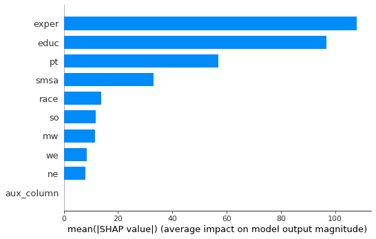

```python
shap.summary_plot(shap_values, X_test, plot_type="bar")
```